# RTD-RAX: Fast, Safe Trajectory Planning for Systems under Unknown Disturbances

MECC 2026 · Tempe, Arizona  
Path Planning and Motion Control I · 08.27.26

Evanns Morales-Cuadrado

School of ECE

Long Kiu Chung

School of ME

Shreyas Kousik

School of ME

Samuel Coogan

School of ECE

# Background

## Robots Must Plan Safely, in Real Time

Robots now share our roads, sidewalks, warehouses, and skies, and must replan safely as the world changes.

[figure not shown]

Autonomous driving[robotsguide.com](https://robotsguide.com/robots/waymo)

[figure not shown]

Sidewalk delivery[serverobotics.com](https://serverobotics.gcs-web.com/news-releases/news-release-details/serve-robotics-brings-autonomous-robot-delivery-atlanta-uber/)

[figure not shown]

Warehouse logistics[qz.com](https://qz.com/709541/amazon-is-just-beginning-to-use-robots-in-its-warehouses-and-theyre-already-making-a-huge-difference)

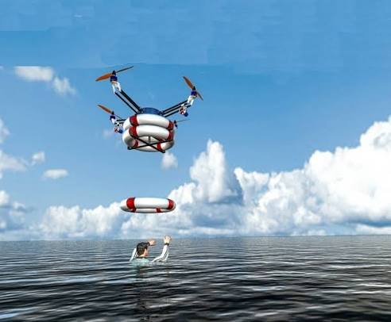

Search & rescue[aerosociety.com](https://www.aerosociety.com/news/life-saving-drones/)

What we want from a planner

FastReplan in milliseconds

Dynamically feasiblePlans the robot can actually track

SafeAvoids every sensed obstacle

Recursively feasibleA certified fail-safe is always ready

Not overly conservativeNo avoidable fail-safes

Disturbance-awareRobust to *a priori* unknown disturbances

We introduce **RTD-RAX**

## Reachability-based Trajectory Design (RTD): Safe Receding-Horizon Planning

1Sensecurrent obstacles

→

2Planfind a safe *k** within *τ*<sub>plan</sub>

→

3Executefollow it for *τ*<sub>plan</sub>, then switch

execute & plan the next segment

failsafe maneuver

0*τ*<sub>plan</sub>*T*

Each plan lasts *T* s, with a fixed planning time *τ*<sub>plan</sub> ∈ (0, *T*): while following the first *τ*<sub>plan</sub> s, RTD plans the next segment. The rest, [*τ*<sub>plan</sub>, *T*], is a **failsafe maneuver**: if no new plan is found in time, the trajectory terminates safely.

[video not shown]

Offline For a family of simple trajectories indexed by a parameter $k$, compute a **forward reachable set (FRS)**: everywhere the robot could end up [1]

Online Rule out every $k$ whose FRS touches an obstacle, then pick the best remaining $k$

$k^\star = \arg\min_{k \,\in\, K_{\text{safe}}} \; J(k)$ $K_{\text{safe}}$: parameters whose FRS avoids all obstacles · $J$: progress toward the goal

## What RTD Gets Right, and What We Want to Improve

What RTD gets right

Fastonline it only solves a small optimization over *k*

Dynamically feasibleplans come from a family the robot can track

Safesensed obstacles become constraints on *k*

Recursively feasibleevery plan ends in a certified fail-safe

1Reachability is slowParameterized FRS tools can be **intractable** for complex, high-dimensional systems

→

2Simplified modelSo, the FRS is computed for a simple **planning model**, not the high-fidelity model

→

3Worst-case boundThe mismatch is treated as a bounded **disturbance** at its worst case

→

4Inflated FRSEvery reachable set is **padded** by that bound

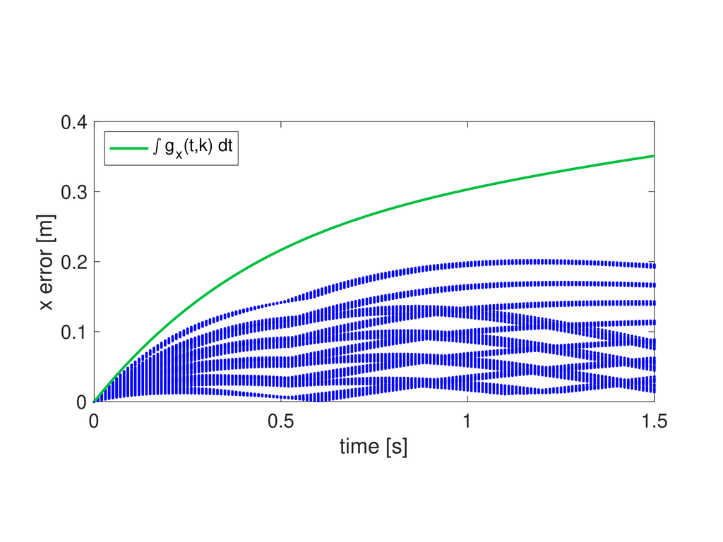

Worst-case bound (green) vs. actual tracking errors (blue). Reproduced from Kousik *et al.* 2020.

Overly conservative Safe passage gets constrained away

[figure not shown]

RTD **does not find** the safe passage.

Blind to runtime disturbances

Every FRS is **pre-computed offline**, so disturbances that show up at runtime (wind, slip, a push) **cannot be accounted for**.

**What if we drop the padding**, and check each plan online with a reachability method fast enough for real time?

# RTD-RAX

## RTD-RAX: Plan → Verify → Repair

RTD planning core

Online verification & repair layer

RTD planner Offline FRS **without padding** + fast optimization over *k*

⟶candidate *k**

Mixed-monotone verification Reachable tube of **this** plan under **current** uncertainty & disturbance bounds

⟶safe

Execute Run the certified plan, then replan

↓unsafe re-verify↑

Repair Nearby candidate: slow down, steer, or tighten constraints

⟶nothing certified in time

Fail-safe Brake along the last certified plan

**RTD’s new job:** *propose* a good plan fast from the FRS **without the worst-case padding**. High-performing plans are no longer thrown out, but unsafe ones may now be proposed

**The verifier’s job:** *prove* a proposed plan is safe with a reachability method tailored for real-time computation along specific trajectories with the **true system dynamics**.

**And a bonus:** because the check runs online, it can also account for **disturbances measured at runtime**. Standard RTD’s pre-computed reachable sets cannot account for such disturbances.

## Certifying a Plan with Mixed-Monotone Reachability

[video not shown]

Every trajectory, under every bounded disturbance, stays inside the box.

$x(0) \in [\underline{x}_0, \overline{x}_0],\; w(t) \in W(t) \;\Longrightarrow\; x(t) \in [\underline{x}(t), \overline{x}(t)]$ mixed-monotone reachability [2], computed with `immrax` [3]

1

Start boxCurrent state ± ε: robot footprint, estimation error, margin

2

Disturbance boundsW(t) = [ŵ − δ, ŵ + δ] from an online estimate

3

Reachable tubeLower and upper bounds follow one ODE, integrated once over the whole plan, braking included

4

Collision check Position boxes $\mathcal{B}_j$ at each sample, plus swept hulls $\mathcal{S}_j$ between consecutive samples, must miss every obstacle

$\mathcal{B}_j \cap X_{\text{obs}} = \varnothing \;\text{ and }\; \mathcal{S}_j \cap X_{\text{obs}} = \varnothing \;\; \forall j \;\Longrightarrow\;$ **certified**

## When a Candidate Fails: Repair, Then Re-Certify

1Speed backoffSlow down so the maneuver is less aggressive

→

2Lateral pushSteer against the estimated disturbance

→

3Tighten constraintsAdd obstacle buffer, re-solve RTD

**Guarantee (safe & recursively feasible).** The robot only executes plans certified over their *full* horizon, braking included. At every moment it is either following a new certified plan or its last plan’s safe termination maneuver.

**Repair is a heuristic** — it may not find a safe plan. Every repaired candidate is re-certified before it runs, and the certified failsafe maneuver is always available if the planning window closes.

What the RAX layer buys Standard RTD failsafes as soon as a planning cycle comes up empty. Repair keeps looking — it **extends the window in which a safe trajectory can still be found**, so the robot keeps making progress instead of stopping. A failed repair costs progress, never safety.

[figure not shown]

Two repairs in Case 2: rejected (pink) → repaired (green)

# Results

## Case 1: A Narrow Gap

**Setup for all cases:** Turtlebot-scale ground robot · unicycle model (position, heading, speed) · RTD plans with a Dubins-car model and 2 parameters *k* = (yaw rate, speed)

[video not shown]

Green ellipse: non-padded RTD reachable set · blue: online mixed-monotone tube.

[figure not shown]

RTD-RAX parameter space: safe *k* exist (white); chosen *k** in green. With padding, every *k* is unsafe.

**Standard RTD**Padding closes the gap → **no feasible plan** → fail-safe braking

**RTD-RAX**Non-padded FRS proposes going straight through → tube **certifies it** → goal reached

Same robot, same obstacles. Conservatism is reduced by **where the safety is certified**: offline or online.

## Case 2: Catching and Repairing Unsafe Plans

[video not shown]

Close-up of the two repairs: the unsafe candidate tube (pink) is rejected, the repaired tube (green) is certified and executed.

**Catch**Without model error inflation, RTD proposes a plan that the verifier determines to be unsafe, so it is **rejected before it runs**.

**Repair**Small adjustments (slow down, steer, tighten constraints) give a nearby plan, which is **re-certified** before it is used.

**Result**Two repairs over 10 planning steps; the robot reaches the goal and **never executes an uncertified plan**. While standard RTD can also find a safe trajectory for this scenario, it inefficiently avoids the obstacle and takes a longer route.

**Note:** the video is paused at each repair step so we can see the process. In the real run, verification and repair take only milliseconds, far too fast to follow.

## Case 3: Disturbances Nobody Planned For

[video not shown]

**Setup**6 m course, three offset gates; before each gate a **disturbance patch** (blue) pushes the robot toward an obstacle

**Standard RTD**The offline FRS can’t see the patches: **collides on planning cycle 3**

**RTD-RAX**Rejects & repairs **3 unsafe plans**, reaches the goal in **19 cycles**

# Conclusion

## Takeaways

RTD-RAX builds upon what RTD already does wellFastDynamically feasibleSafeRecursively feasiblewhile making it:

Less conservative

A non-padded FRS plus an online check recovers maneuvers standard RTD rejects, like the narrow gap.

Disturbance-aware

The first RTD-based planner certified safe under disturbances **not known ahead of time**.

Still real-time

About **1.2 ms** added to a ~10 ms planning cycle, thanks to JIT-compiled mixed-monotone reachability.

**RTD proposes, fast mixed-monotone reachability certifies,**  
**and clever repairs turn rejected plans into continued mission progress**

## Thank You

**RTD-RAX:** Fast, Safe Trajectory Planning for Systems under Unknown Disturbances

Evanns Morales-Cuadrado · Long Kiu Chung · Shreyas Kousik · Samuel Coogan · Georgia Tech

Paper[`arxiv.org/abs/2603.21635`](https://arxiv.org/abs/2603.21635)

Project[`evannsmc.github.io/ws_RTD`](https://evannsmc.github.io/ws_RTD)

Code[`github.com/evannsmc/rtd-rax`](https://github.com/evannsmc/rtd-rax)

Docker`docker pull evannsmc/rtd-rax`

Contact`egm@gatech.edu`

[figure not shown]

Project site: code, docs, animations

Supported in part by the National Science Foundation under Awards #2333488 and #2219755 and by the Air Force Office of Scientific Research under Grant FA9550-23-1-0303. L. K. Chung was supported by NSF Award #2449160.

# Backup

## **Backup.** RTD — Planning Model & Trajectory Parameters

**High-fidelity model** (unicycle, state $(x, y, h, v)$):
$$\dot x = v\cos h, \quad \dot y = v\sin h, \quad \dot h = \omega, \quad \dot v = a$$
inputs: yaw rate $\omega$, longitudinal acceleration $a$.

**Planning model** (Dubins car on shared states $z = (x, y, h)$):
$$\dot x = v_{\text{des}}\cos h, \quad \dot y = v_{\text{des}}\sin h, \quad \dot h = \omega_{\text{des}}$$

- Full 4-state dynamics are too expensive for the offline SOS reachable-set computation [1]
- $(\omega_{\text{des}}, v_{\text{des}})$ are **held constant** over each plan, so one $k$ fixes one trajectory

**Parameters** $k = (k_1, k_2) \in [-1, 1]^2$ decode as
$$\omega_{\text{des}} = \omega_{\max}\, k_1, \qquad v_{\text{des}} = \tfrac{v_{\max}}{2}\,(k_2 + 1)$$

**Two-phase trajectory**, horizon $T = t_{\text{plan}} + t_{\text{stop}}$:

- cruise for $t_{\text{plan}}$, then scale $\omega$ and $v$ linearly to zero over $t_{\text{stop}}$
- the braking tail is **part of every certified plan**, so it is the fail-safe

**Implementation values:** $t_{\text{plan}} = 0.5$ s · $t_{\text{stop}} = v_{\text{des}}/a_{\max}$ with $a_{\max} = 2$ m/s² · $\omega_{\max} = 1$ rad/s · FRS speed range 0.25–1.25 m/s · robot radius 0.175 m

## **Backup.** RTD — Tracking Error & the Forward Reachable Set

**Trajectory-tracking model.** Tracking-error bound $g$ and any $d \in L_d = L^1([0,T], [-1,1]^{n_Z})$:
$$\dot z_i(t) = f_{\text{des},i}(t, z(t), k) + g_i(t, k)\, d_i(t), \qquad i = 1, \dots, n_Z$$
Every high-fidelity trajectory tracking $k$ is matched by some $d \in L_d$ [1, Lemma 16].

**FRS** (over-approximated offline):
$$X_{\text{FRS}} = \bigl\{ (\hat z, \hat k) \mid \exists\, t \in [0,T],\, z_0 \in Z_0,\, d \in L_d : z(0) = z_0,\; z(t) = \hat z \bigr\}$$

**Safe parameters** for obstacles $X_{\text{obs}}$:
$$\pi_K(X') = \{ k \mid \exists z \in X' : (z, k) \in X_{\text{FRS}} \}, \qquad K_{\text{safe}} = K \setminus \pi_K(X_{\text{obs}})$$

**RTD-RAX:** use the **non-inflated** FRS ($g \equiv 0$) only to *propose* $k^\star$; certification moves online.

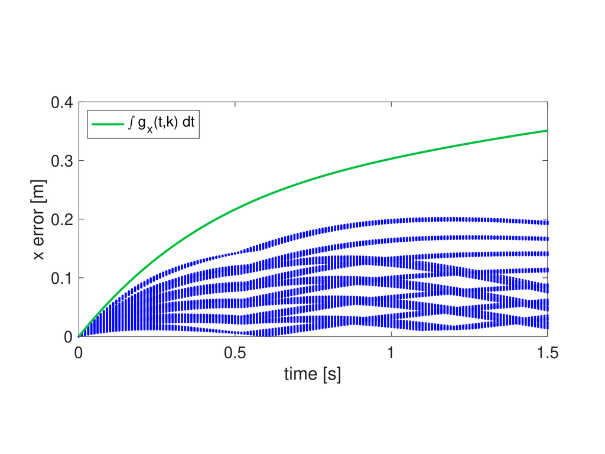

## **Backup.** Mixed-Monotone Reachability: One Box Holds Every Trajectory

[video not shown]

Every sampled trajectory, under every disturbance w ∈ [−1, 1], stays inside the box.

- Instead of simulating every possible trajectory, track just a **lower and upper bound** on each state [2]
- The bounds follow **their own ODE**, twice the size of the robot model, integrated **once** per candidate
- Boxes are conservative, but much less than standard RTD, and **fast**: `immrax` builds and JIT-compiles the bound dynamics automatically [3]

$x(0) \in [\underline{x}_0, \overline{x}_0],\;\; w(t) \in [\underline{w}, \overline{w}] \;\;\Longrightarrow\;\; x(t) \in [\underline{x}(t), \overline{x}(t)] \quad \forall\, t \ge 0$ start anywhere in the box, suffer any bounded disturbance, and the true state is still inside the propagated box

## **Backup.** Mixed Monotonicity — Inclusion Function & Embedding System

For $\dot x = f(x, u, w)$, an **inclusion function** $\mathcal F = [\underline{\mathcal F}, \overline{\mathcal F}]$ satisfies, for all $x \in [\underline x, \overline x]$, $u \in [\underline u, \overline u]$, $w \in [\underline w, \overline w]$:
$$f(x, u, w) \in \mathcal F\bigl([\underline x, \overline x], [\underline u, \overline u], [\underline w, \overline w]\bigr)$$

**Embedding system** ($2n$ states; $x_{[i:y]}$ replaces the $i$-th entry of $x$ with $y_i$):
$$\begin{aligned}
\dot{\underline x}_i &= \underline{\mathcal F}\bigl([\underline x, \overline x_{[i:\underline x]}], [\underline u, \overline u], [\underline w, \overline w]\bigr)_i \\
\dot{\overline x}_i &= \overline{\mathcal F}\bigl([\underline x_{[i:\overline x]}, \overline x], [\underline u, \overline u], [\underline w, \overline w]\bigr)_i
\end{aligned}$$

Monotone w.r.t. the southeast order $(x, x') \preceq_{\text{SE}} (y, y') \iff [y, y'] \subseteq [x, x']$ [2].

**Enclosure guarantee** for all $T \ge 0$:
$$\phi(T; x_0, u, w) \in \bigl[\!\bigl[ \Phi^{\mathcal E}(T; [\underline x_0, \overline x_0], [\underline u, \overline u], [\underline w, \overline w]) \bigr]\!\bigr]$$

- Exists for any vector field locally Lipschitz in state and disturbance [4, Thm. 1]
- `immrax` derives $\mathcal F$ by JAX tracing + interval arithmetic and JIT-compiles $\mathcal E$ [3]

## **Backup.** Certifying a Candidate Online

1Start boxCurrent state ± ε: robot footprint, estimation error, margin

→

2Disturbance boundsW(t) = [ŵ − δ, ŵ + δ] from an online estimate

→

3Reachable tubePropagate the bounds over the whole plan, braking included

→

4Collision checkPosition boxes + swept hulls between samples vs. obstacles

[figure not shown]

$\mathcal{B}_j \cap X_{\text{obs}} = \varnothing \;\text{ and }\; \mathcal{S}_j \cap X_{\text{obs}} = \varnothing \;\; \forall j \;\Longrightarrow\;$ **certified**

## **Backup.** Verification — Uncertainty, Tube & Swept Hulls

**Verification dynamics** for candidate $k^\star$: $\dot x = f(x, u_{k^\star}(t), w)$, full state $x$.

**Initial set:** $x(0) \in [\hat x_0 - \varepsilon,\; \hat x_0 + \varepsilon]$ (estimation error + footprint + margin)

**Disturbance set:** $w(t) \in W(t) = [\hat w(t) - \delta(t),\; \hat w(t) + \delta(t)]$, where $|w_i - \hat w_i| \le \delta_i$; $\delta$ may also absorb model mismatch and delay. GP confidence bounds give a probabilistic certificate [5].

**Tube:** $\mathcal R_j = [\underline x(t_j), \overline x(t_j)]$, position boxes $\mathcal B_j = [\underline x_{\text{pos}}(t_j), \overline x_{\text{pos}}(t_j)]$

**Swept interval hull** between samples:
$$\mathcal S_j = \bigl[ \min(\underline x_{\text{pos}}(t_j), \underline x_{\text{pos}}(t_{j+1})),\; \max(\overline x_{\text{pos}}(t_j), \overline x_{\text{pos}}(t_{j+1})) \bigr]$$
assumes $\Delta t$ small enough that inter-sample deviation is covered.

**Implementation** (`immrax_verify.py`)

- Additive disturbance on $(\dot x, \dot y, \dot h, \dot v)$; interval radii carried in the embedding state
- $\varepsilon_{\text{pos}} = r_{\text{robot}} + \varepsilon_{\text{add}}$ with $r_{\text{robot}} = 0.175$ m; $\varepsilon_h = \varepsilon_v = 0.2\,\varepsilon_{\text{pos}}$
- $\varepsilon_{\text{add}} = 0.01$ m (Cases 1, 3), $0.03$ m (Case 2)
- Natural inclusion (`irx.natemb`), RK45, $\Delta t = 0.01$ s over the full $T$
- Check boxes first, then hulls; report the **earliest** collision time for repair
- Case 2: fixed bound $|w| \le (0.017, 0.060, 0.043, 0.017)$ on $(\dot x, \dot y, \dot h, \dot v)$
- Case 3: symmetric bound from the patches along the candidate’s reference path

## **Backup.** Repair Procedure & Safety Theorem

**Repair order** (each candidate re-verified before execution):

1. **Speed backoff:** $k_2 \leftarrow k_2 - \Delta_v$
2. **Lateral push:** $k_1 \leftarrow k_1 \pm \Delta_\omega$, trying the direction opposing the estimated lateral disturbance first
3. **Constraint tightening:** obstacle buffer $b \leftarrow b + \Delta_b$, re-solve the RTD program

**Settings in the paper’s runs** (`docker/makefile`)

- Case 2: $\Delta_v = 0.08$, $\Delta_b = 0.01$ m, up to 2 rounds
- Case 3: $\Delta_v = 0.08$, $\Delta_b = 0.015$ m, up to 4 rounds
- Lateral push is implemented but **disabled** in both runs

Repair is a candidate-generation heuristic: not complete, not assumed convergent. Failure costs progress, never safety.

**Theorem (safety & recursive feasibility).** Let each executed candidate have horizon $T = t_{\text{plan}} + t_{\text{stop}}$ whose last $t_{\text{stop}}$ seconds are a fail-safe stop. If the initial candidate is certified over its full horizon, the system only switches to candidates certified over their full horizons, and it executes the current fail-safe whenever no new candidate is certified within $t_{\text{plan}}$, then RTD-RAX is safe and recursively feasible.

*Proof sketch.* Certification gives $\operatorname{proj}_{\text{pos}}(\mathcal R_k(t)) \cap X_{\text{obs}} = \varnothing$ for all $t \in [0, T]$, covering both cruise and braking. At the next planning instant the system either switches to a newly certified candidate or continues the certified stop. Apply recursively. $\square$

## **Backup.** Future Work

**Method**

- **Tighter coupling** between the RTD optimization and the online reachable tube, so replanning can take gradient steps instead of guess-and-check repair
- **Learned disturbance bounds** in place of measured ones: Gaussian-process confidence bounds give a tube that holds with a prescribed probability [5]
- Richer disturbance and uncertainty descriptions generally

**Validation**

- **Hardware**: port the case studies to a ground robot, then a quadrotor, where the tube grows faster in higher dimensions
- **Head-to-head against robust and tube-based MPC** under common models, disturbance assumptions, safety specifications, and compute budgets

RTD-RAX and robust/tube MPC split the work differently: MPC folds dynamics, uncertainty and constraints into one receding-horizon optimization, while RTD-RAX generates candidates from a precomputed FRS and verifies each one online.

## References

[1]

S. Kousik, S. Vaskov, F. Bu, M. Johnson-Roberson and R. Vasudevan, “[Bridging the gap between safety and real-time performance in receding-horizon trajectory design for mobile robots](https://doi.org/10.1177/0278364920943266),” *The International Journal of Robotics Research*, 2020.

[2]

S. Coogan, “[Mixed monotonicity for reachability and safety in dynamical systems](https://doi.org/10.1109/CDC42340.2020.9304278),” *59th IEEE conference on decision and control (CDC)*, 2020.

[3]

A. Harapanahalli, S. Jafarpour and S. Coogan, “[Immrax: A parallelizable and differentiable toolbox for interval analysis and mixed monotone reachability in JAX](https://doi.org/10.1016/j.ifacol.2024.07.428),” *IFAC-PapersOnLine*, 2024.

[4]

M. Abate, M. Dutreix and S. Coogan, “Tight decomposition functions for continuous-time mixed-monotone systems with disturbances,” *IEEE Control Systems Letters*, 2020.

[5]

M. E. Cao and S. Coogan, “[Trajectory tracking runtime assurance for systems with partially unknown dynamics](https://doi.org/10.1109/ICRA57147.2024.10611237),” *IEEE international conference on robotics and automation (ICRA)*, 2024.